# BANA698_Environmental_Preprocessing

## **Initial Summary Statistics by Region**

```python
import pandas as pd

file_path = "/content/env_stat_summary.csv"
df = pd.read_csv(file_path)
df.head()
```

|  | region | total_records | mean_electricity_access | median_electricity_access | stddev_electricity_access | mean_co2_agriculture | median_co2_agriculture | stddev_co2_agriculture | mean_co2_transport | median_co2_transport | stddev_co2_transport | mean_co2_waste | median_co2_waste | stddev_co2_waste | mean_forest_area | median_forest_area | stddev_forest_area | mean_renewable_energy | median_renewable_energy | stddev_renewable_energy | mean_ghg_emissions | median_ghg_emissions | stddev_ghg_emissions |
| --- | --- | --- | --- | --- | --- | --- | --- | --- | --- | --- | --- | --- | --- | --- | --- | --- | --- | --- | --- | --- | --- | --- | --- |
| 0 | East Asia and Pacific | 111 | 60.251351 | 92.8 | 46.439346 | 0.955335 | 0.0000 | 2.715880 | 48.100141 | 1.7875 | 164.187691 | 0.245309 | 0.0009 | 0.806394 | 30.420019 | 24.226046 | 30.481800 | 9.155856 | 0.4 | 15.781668 | 8.301835 | 3.598783 | 14.196181 |
| 1 | Europe and Central Asia | 174 | 65.508621 | 100.0 | 47.662131 | 0.453471 | 0.0561 | 0.956486 | 23.674526 | 7.5765 | 45.344028 | 0.132708 | 0.0010 | 0.606930 | 18.081419 | 11.029667 | 20.009604 | 7.794253 | 0.0 | 14.852129 | 6.786218 | 6.481516 | 4.463806 |
| 2 | Latin America and the Caribbean | 126 | 65.053175 | 98.6 | 46.664376 | 0.541188 | 0.0000 | 2.034740 | 13.804961 | 1.4529 | 37.008596 | 0.021644 | 0.0000 | 0.087777 | 27.284134 | 24.657473 | 26.519414 | 7.343651 | 0.0 | 14.743712 | 4.300075 | 3.502919 | 4.147293 |
| 3 | Middle East and North Africa | 63 | 63.474603 | 99.9 | 46.073945 | 0.258895 | 0.0148 | 0.668533 | 27.659551 | 14.0773 | 39.061885 | 0.000175 | 0.0000 | 0.000506 | 1.841691 | 0.253378 | 3.516258 | 2.496825 | 0.0 | 5.849978 | 13.353623 | 5.673357 | 15.412068 |
| 4 | North America | 9 | 66.666667 | 100.0 | 50.000000 | 3.357056 | 3.7035 | 2.760139 | 617.959322 | 164.2478 | 808.130777 | 0.037978 | 0.0034 | 0.054469 | 20.411882 | 18.518519 | 17.122551 | 4.055556 | 0.0 | 8.207026 | 14.202102 | 18.062548 | 6.420438 |

```python
print(df.dtypes)
df.describe()
```

```
region                        object
total_records                  int64
mean_electricity_access      float64
median_electricity_access    float64
stddev_electricity_access    float64
mean_co2_agriculture         float64
median_co2_agriculture       float64
stddev_co2_agriculture       float64
mean_co2_transport           float64
median_co2_transport         float64
stddev_co2_transport         float64
mean_co2_waste               float64
median_co2_waste             float64
stddev_co2_waste             float64
mean_forest_area             float64
median_forest_area           float64
stddev_forest_area           float64
mean_renewable_energy        float64
median_renewable_energy      float64
stddev_renewable_energy      float64
mean_ghg_emissions           float64
median_ghg_emissions         float64
stddev_ghg_emissions         float64
dtype: object
```

|  | total_records | mean_electricity_access | median_electricity_access | stddev_electricity_access | mean_co2_agriculture | median_co2_agriculture | stddev_co2_agriculture | mean_co2_transport | median_co2_transport | stddev_co2_transport | mean_co2_waste | median_co2_waste | stddev_co2_waste | mean_forest_area | median_forest_area | stddev_forest_area | mean_renewable_energy | median_renewable_energy | stddev_renewable_energy | mean_ghg_emissions | median_ghg_emissions | stddev_ghg_emissions |
| --- | --- | --- | --- | --- | --- | --- | --- | --- | --- | --- | --- | --- | --- | --- | --- | --- | --- | --- | --- | --- | --- | --- |
| count | 11.000000 | 11.000000 | 11.000000 | 11.000000 | 11.000000 | 11.000000 | 11.000000 | 11.000000 | 11.000000 | 11.000000 | 11.000000 | 11.000000 | 11.000000 | 11.000000 | 11.000000 | 11.000000 | 11.000000 | 11.000000 | 11.000000 | 11.000000 | 11.000000 | 11.000000 |
| mean | 72.545455 | 54.069737 | 78.349238 | 41.369573 | 18.989543 | 16.710668 | 6.618708 | 989.516938 | 914.784437 | 314.900079 | 2.138178 | 1.715036 | 0.820917 | 17.800999 | 15.273080 | 18.065251 | 7.177553 | 0.036364 | 11.225868 | 6.330302 | 5.112460 | 5.077793 |
| std | 60.221863 | 19.975532 | 33.136377 | 14.670475 | 43.074597 | 42.963857 | 12.018418 | 2357.049405 | 2374.556666 | 448.471030 | 5.337189 | 5.362801 | 1.485764 | 9.266937 | 10.974609 | 9.250084 | 9.412986 | 0.120605 | 12.194281 | 4.370993 | 4.776295 | 5.183939 |
| min | 3.000000 | 0.000000 | 0.000000 | 0.000000 | 0.000000 | 0.000000 | 0.000000 | 0.000000 | 0.000000 | 0.000000 | 0.000000 | 0.000000 | 0.000000 | 0.000000 | 0.000000 | 0.000000 | 0.000000 | 0.000000 | 0.000000 | 0.000000 | 0.000000 | 0.000000 |
| 25% | 16.500000 | 56.372606 | 74.281881 | 43.148112 | 0.356183 | 0.000000 | 0.483669 | 18.739743 | 1.620200 | 38.035241 | 0.000383 | 0.000000 | 0.001390 | 17.182870 | 6.814998 | 15.714799 | 0.000000 | 0.000000 | 0.000000 | 3.446536 | 2.708384 | 1.877429 |
| 50% | 63.000000 | 60.870948 | 92.800000 | 46.439346 | 0.955335 | 0.056100 | 2.034740 | 48.100141 | 7.576500 | 105.443837 | 0.037978 | 0.000900 | 0.087777 | 20.127130 | 18.518519 | 20.009604 | 4.055556 | 0.000000 | 8.207026 | 6.312356 | 3.604205 | 3.837602 |
| 75% | 118.500000 | 64.845337 | 99.250000 | 47.246059 | 8.873769 | 4.618100 | 6.315707 | 580.068047 | 286.224850 | 412.782648 | 0.892225 | 0.008950 | 0.706662 | 21.051773 | 24.441759 | 23.289421 | 8.475054 | 0.000000 | 15.316899 | 7.544026 | 6.020970 | 5.442122 |
| max | 174.000000 | 66.666667 | 100.000000 | 52.715795 | 143.319999 | 143.249643 | 40.605901 | 7939.083771 | 7943.501403 | 1428.492211 | 17.865591 | 17.859999 | 4.533690 | 30.420019 | 31.143041 | 30.481800 | 30.152778 | 0.400000 | 36.112886 | 14.202102 | 18.062548 | 15.412068 |

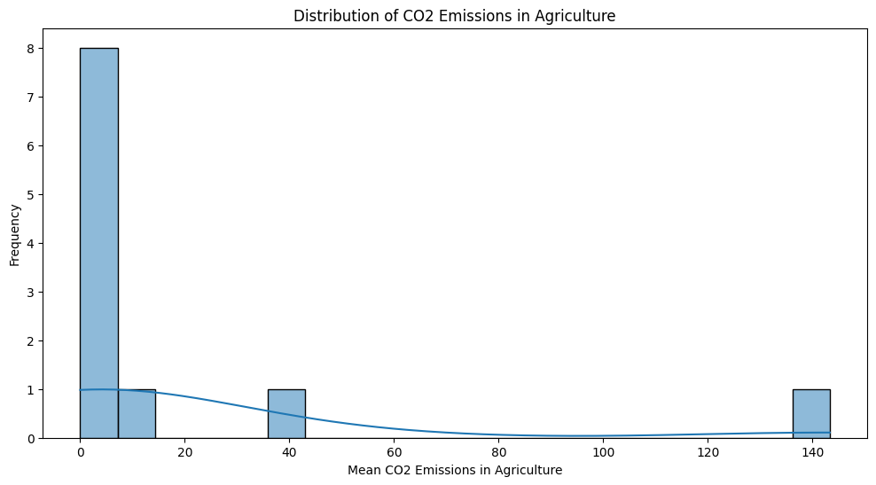

```python
import matplotlib.pyplot as plt
import seaborn as sns

plt.figure(figsize=(12, 6))

sns.histplot(df["mean_co2_agriculture"], bins=20, kde=True)
plt.xlabel("Mean CO2 Emissions in Agriculture")
plt.ylabel("Frequency")
plt.title("Distribution of CO2 Emissions in Agriculture")
plt.show()
```

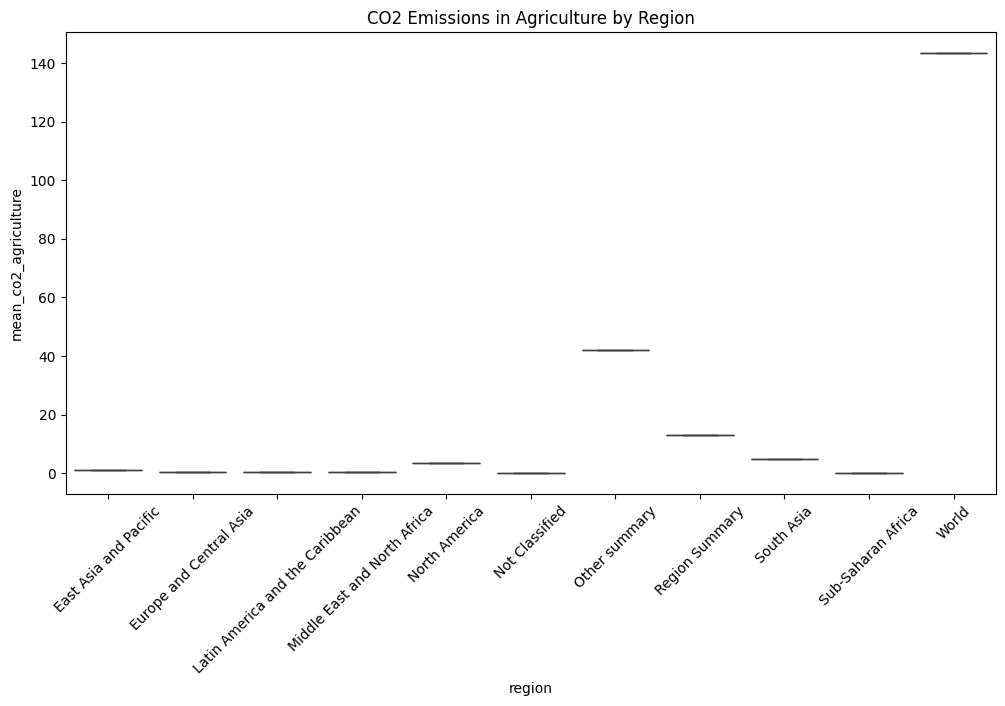

```python
plt.figure(figsize=(12, 6))
sns.boxplot(x="region", y="mean_co2_agriculture", data=df)
plt.xticks(rotation=45)
plt.title("CO2 Emissions in Agriculture by Region")
plt.show()
```

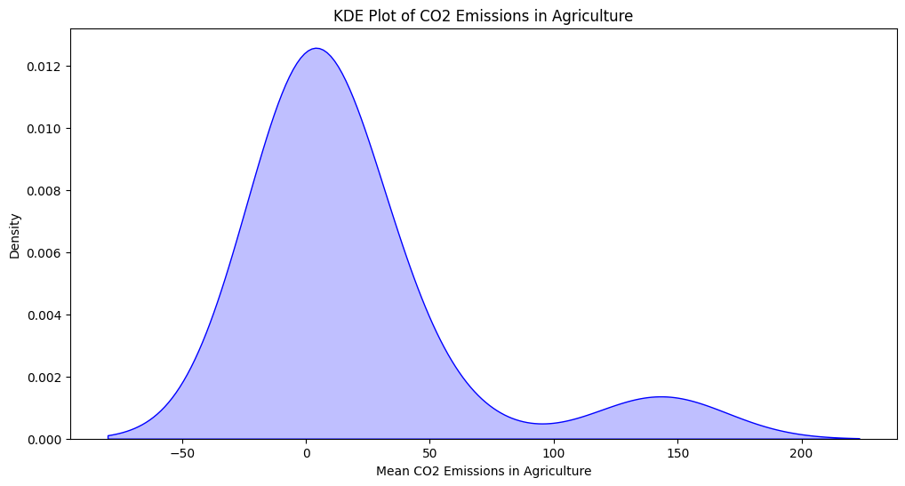

```python
plt.figure(figsize=(12, 6))
sns.kdeplot(df["mean_co2_agriculture"], shade=True, color="blue")
plt.xlabel("Mean CO2 Emissions in Agriculture")
plt.title("KDE Plot of CO2 Emissions in Agriculture")
plt.show()
```

## **Summary Statistics by Country**

```python
import pandas as pd

file_path = "/content/forcleaning_environmental_indicators.csv"
df = pd.read_csv(file_path)
df.head()
```

|  | country_code | year | ElectricityAccess_PercentofPopulation | CO2Emissions_Agriculture | CO2Emissions_TransportEnergy | CO2Emissions_Waste | ForestArea_PercentofLand | RenewableEnergy_Consumption_Percent | GreenhouseGasEmissions_TotalperCapita | id | country_name | region |
| --- | --- | --- | --- | --- | --- | --- | --- | --- | --- | --- | --- | --- |
| 0 | AFE | 2023 | 0.0 | 2.7684 | 122.0590 | 0.0032 | 0.0 | 0.0 | 1.958972 | NaN | Africa Eastern and Southern | Region Summary |
| 1 | AFW | 2023 | 0.0 | 2.0538 | 102.7708 | 0.0119 | 0.0 | 0.0 | 1.778662 | NaN | Africa Western and Central | Region Summary |
| 2 | ARB | 2023 | 0.0 | 3.6728 | 455.0742 | 0.0035 | 0.0 | 0.0 | 6.527345 | NaN | Arab World | Region Summary |
| 3 | ARG | 2023 | 0.0 | 2.4059 | 47.4454 | 0.0120 | 0.0 | 0.0 | 8.030247 | NaN | Argentina | Latin America and the Caribbean |
| 4 | BGR | 2023 | 0.0 | 0.7915 | 9.4078 | 0.0013 | 0.0 | 0.0 | 8.279145 | NaN | Bulgaria | Europe and Central Asia |

```python
# Check the data types and missing values
df.info()
df.describe()
```

```
<class 'pandas.core.frame.DataFrame'>
RangeIndex: 798 entries, 0 to 797
Data columns (total 12 columns):
 #   Column                                 Non-Null Count  Dtype
---  ------                                 --------------  -----
 0   country_code                           798 non-null    object
 1   year                                   798 non-null    int64
 2   ElectricityAccess_PercentofPopulation  798 non-null    float64
 3   CO2Emissions_Agriculture               798 non-null    float64
 4   CO2Emissions_TransportEnergy           798 non-null    float64
 5   CO2Emissions_Waste                     798 non-null    float64
 6   ForestArea_PercentofLand               798 non-null    float64
 7   RenewableEnergy_Consumption_Percent    798 non-null    float64
 8   GreenhouseGasEmissions_TotalperCapita  798 non-null    float64
 9   id                                     0 non-null      float64
 10  country_name                           798 non-null    object
 11  region                                 798 non-null    object
dtypes: float64(8), int64(1), object(3)
memory usage: 74.9+ KB
```

|  | year | ElectricityAccess_PercentofPopulation | CO2Emissions_Agriculture | CO2Emissions_TransportEnergy | CO2Emissions_Waste | ForestArea_PercentofLand | RenewableEnergy_Consumption_Percent | GreenhouseGasEmissions_TotalperCapita | id |
| --- | --- | --- | --- | --- | --- | --- | --- | --- | --- |
| count | 798.000000 | 798.000000 | 798.000000 | 798.000000 | 798.000000 | 798.000000 | 798.000000 | 798.000000 | 0.0 |
| mean | 2022.000000 | 57.352673 | 5.447508 | 227.985439 | 0.558783 | 20.678179 | 10.356516 | 6.078756 | NaN |
| std | 0.817009 | 45.180367 | 18.182632 | 769.251923 | 2.134052 | 23.831627 | 21.838748 | 8.148832 | NaN |
| min | 2021.000000 | 0.000000 | 0.000000 | 0.000000 | 0.000000 | 0.000000 | 0.000000 | 0.000000 | NaN |
| 25% | 2021.000000 | 0.000000 | 0.000000 | 0.767200 | 0.000000 | 0.000000 | 0.000000 | 1.780949 | NaN |
| 50% | 2022.000000 | 83.250000 | 0.039300 | 5.514150 | 0.000100 | 11.367703 | 0.000000 | 4.126462 | NaN |
| 75% | 2023.000000 | 100.000000 | 1.419775 | 56.880725 | 0.012300 | 35.175673 | 8.525000 | 7.847613 | NaN |
| max | 2023.000000 | 100.000000 | 143.618297 | 8239.044960 | 17.997356 | 94.600146 | 96.300000 | 84.712585 | NaN |

### **Preprocessing for Indicator: Electricity Access %**

```python
invalid_values = df[(df["ElectricityAccess_PercentofPopulation"] < 0) | (df["ElectricityAccess_PercentofPopulation"] > 100)]

invalid_values
```

|  | country_code | year | ElectricityAccess_PercentofPopulation | CO2Emissions_Agriculture | CO2Emissions_TransportEnergy | CO2Emissions_Waste | ForestArea_PercentofLand | RenewableEnergy_Consumption_Percent | GreenhouseGasEmissions_TotalperCapita | id | country_name | region |
| --- | --- | --- | --- | --- | --- | --- | --- | --- | --- | --- | --- | --- |

**Check for outliers based on IQR:**

```python
import numpy as np

col = "ElectricityAccess_PercentofPopulation"

Q1 = df[col].quantile(0.25)
Q3 = df[col].quantile(0.75)
IQR = Q3 - Q1

lower_bound = Q1 - 1.5 * IQR
upper_bound = Q3 + 1.5 * IQR

outliers = df[(df[col] < lower_bound) | (df[col] > upper_bound)]
outliers
```

|  | country_code | year | ElectricityAccess_PercentofPopulation | CO2Emissions_Agriculture | CO2Emissions_TransportEnergy | CO2Emissions_Waste | ForestArea_PercentofLand | RenewableEnergy_Consumption_Percent | GreenhouseGasEmissions_TotalperCapita | id | country_name | region |
| --- | --- | --- | --- | --- | --- | --- | --- | --- | --- | --- | --- | --- |

**Keep indicator data as is - all values are withing expected ranges, as the indicator should be a percentage between 0-100**

### **Preprocessing for Indicator: C02 Emissions Indicators (Agriculture, Transport, and Waste) Range: 0-80**

```python
# Count zero values in each CO₂ emissions column
co2_columns = ["CO2Emissions_Agriculture", "CO2Emissions_TransportEnergy", "CO2Emissions_Waste"]
zero_counts = (df[co2_columns] == 0).sum()
print("Zero values in CO₂ emissions columns:\n", zero_counts)
```

```
Zero values in CO₂ emissions columns:
 CO2Emissions_Agriculture        336
CO2Emissions_TransportEnergy     72
CO2Emissions_Waste              390
dtype: int64
```

```python
def detect_outliers_iqr(data, column):
    Q1 = data[column].quantile(0.25)
    Q3 = data[column].quantile(0.75)
    IQR = Q3 - Q1
    lower_bound = Q1 - 1.5 * IQR
    upper_bound = Q3 + 1.5 * IQR

    outliers = data[(data[column] < lower_bound) | (data[column] > upper_bound)]

    return outliers

outliers_agriculture = detect_outliers_iqr(df, "CO2Emissions_Agriculture")
outliers_transport = detect_outliers_iqr(df, "CO2Emissions_TransportEnergy")
outliers_waste = detect_outliers_iqr(df, "CO2Emissions_Waste")

print("Outliers detected:")
print(f"Agriculture: {len(outliers_agriculture)}")
print(f"Transport: {len(outliers_transport)}")
print(f"Waste: {len(outliers_waste)}")
```

```
Outliers detected:
Agriculture: 141
Transport: 143
Waste: 159
```

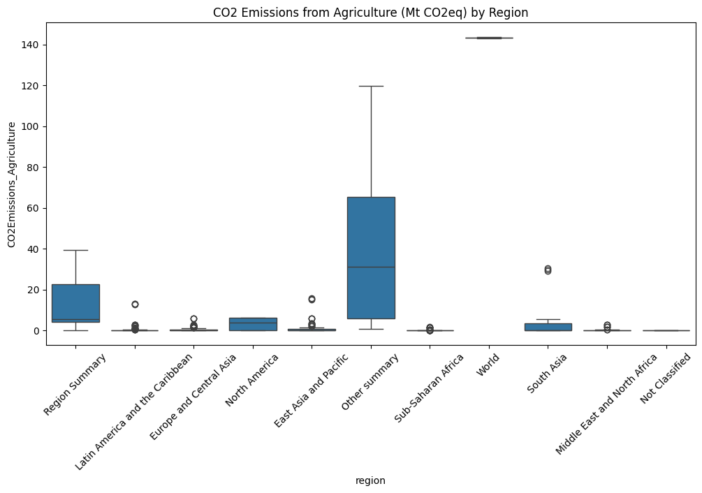

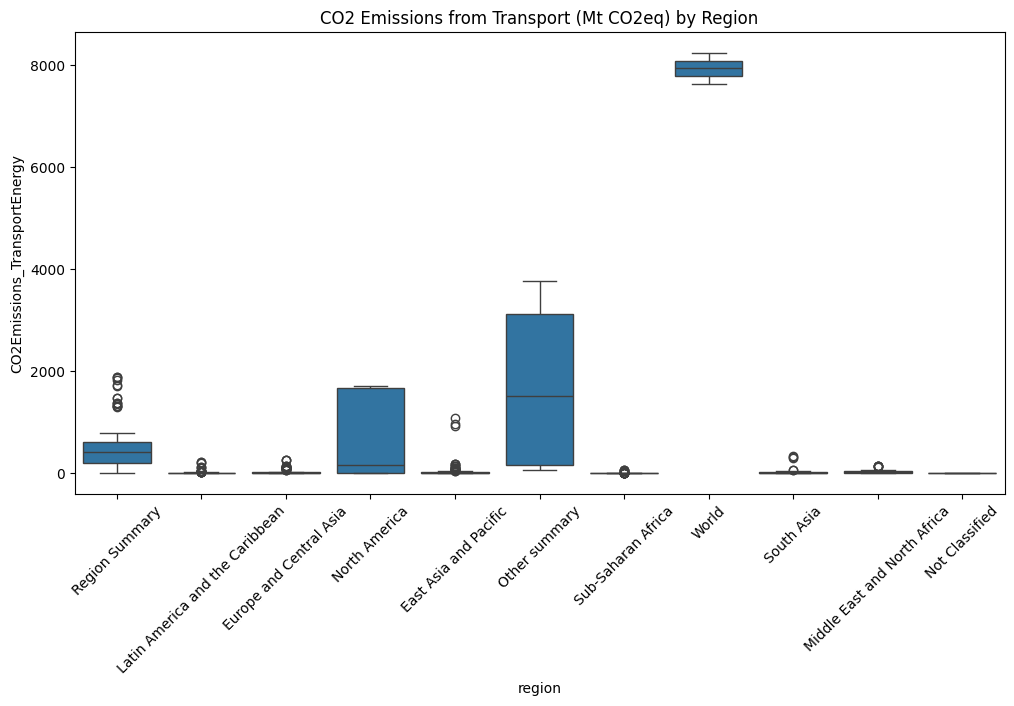

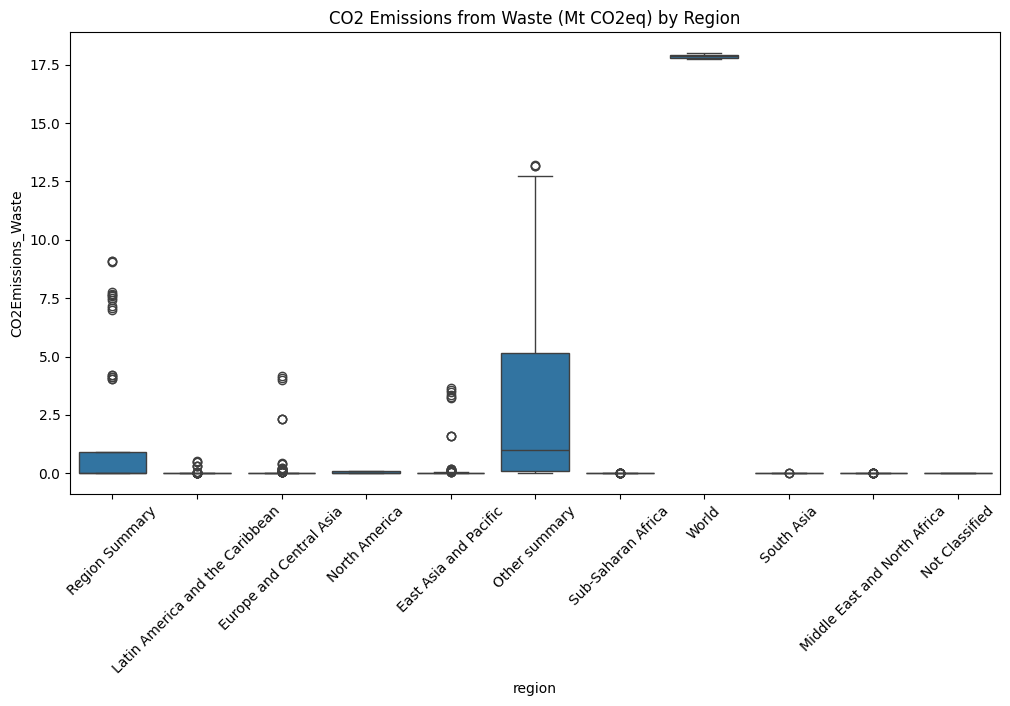

```python
import seaborn as sns
import matplotlib.pyplot as plt

def plot_boxplot(column, title):
    plt.figure(figsize=(12, 6))
    sns.boxplot(x="region", y=column, data=df)
    plt.xticks(rotation=45)
    plt.title(title)
    plt.show()

plot_boxplot("CO2Emissions_Agriculture", "CO2 Emissions from Agriculture (Mt CO2eq) by Region")
plot_boxplot("CO2Emissions_TransportEnergy", "CO2 Emissions from Transport (Mt CO2eq) by Region")
plot_boxplot("CO2Emissions_Waste", "CO2 Emissions from Waste (Mt CO2eq) by Region")
```

**Remove certain region labels, given they are not actual regions and are instead categories summarized at a different level**

```python
excluded_regions = ["Region Summary", "World", "Other summary", "Not Classified"]

df_filtered = df[~df["region"].isin(excluded_regions)].copy()

print("Remaining Regions in Dataset:", df_filtered["region"].unique())
```

```
Remaining Regions in Dataset: ['Latin America and the Caribbean' 'Europe and Central Asia'
 'North America' 'East Asia and Pacific' 'Sub-Saharan Africa' 'South Asia'
 'Middle East and North Africa']
```

**Check for outliers again with filtered regions. Result is less outliers based on IQR**

```python
def detect_outliers_iqr(data, column):
    Q1 = data[column].quantile(0.25)
    Q3 = data[column].quantile(0.75)
    IQR = Q3 - Q1
    lower_bound = Q1 - 1.5 * IQR
    upper_bound = Q3 + 1.5 * IQR

    outliers = data[(data[column] < lower_bound) | (data[column] > upper_bound)]

    return outliers

outliers_agriculture = detect_outliers_iqr(df_filtered, "CO2Emissions_Agriculture")
outliers_transport = detect_outliers_iqr(df_filtered, "CO2Emissions_TransportEnergy")
outliers_waste = detect_outliers_iqr(df_filtered, "CO2Emissions_Waste")

print("Outliers detected (after filtering regions):")
print(f"Agriculture: {len(outliers_agriculture)}")
print(f"Transport: {len(outliers_transport)}")
print(f"Waste: {len(outliers_waste)}")
```

```
Outliers detected (after filtering regions):
Agriculture: 125
Transport: 96
Waste: 124
```

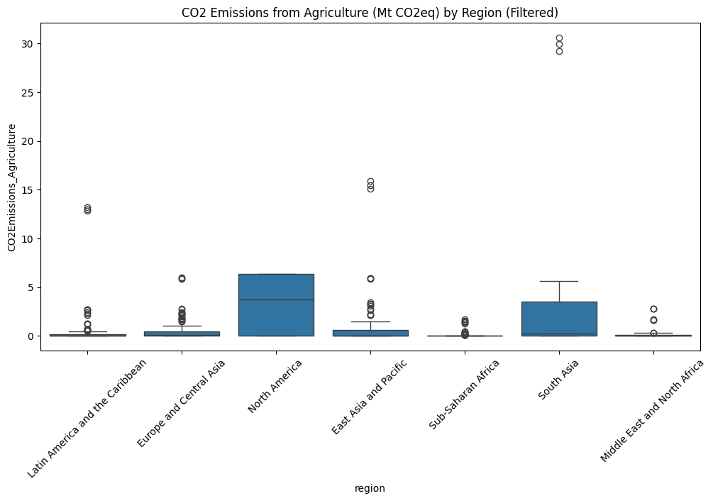

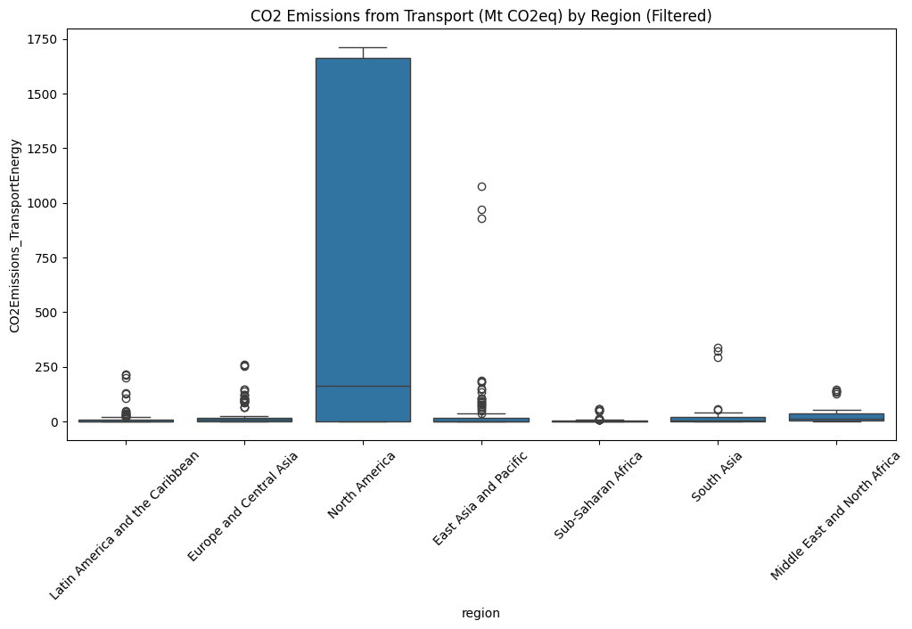

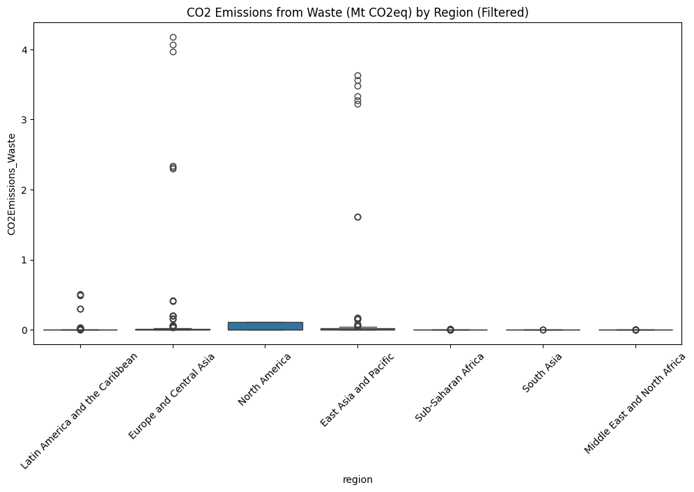

```python
def plot_boxplot(data, column, title):
    plt.figure(figsize=(12, 6))
    sns.boxplot(x="region", y=column, data=data)
    plt.xticks(rotation=45)
    plt.title(title)
    plt.show()

plot_boxplot(df_filtered, "CO2Emissions_Agriculture", "CO2 Emissions from Agriculture (Mt CO2eq) by Region (Filtered)")
plot_boxplot(df_filtered, "CO2Emissions_TransportEnergy", "CO2 Emissions from Transport (Mt CO2eq) by Region (Filtered)")
plot_boxplot(df_filtered, "CO2Emissions_Waste", "CO2 Emissions from Waste (Mt CO2eq) by Region (Filtered)")
```

**There are still regions with outliers (as shown by the boxplots), however these outliers may be acceptable (i.e., there may be some countries that are expected to have significantly higher CO2 Emissions than others)**

**We also need to validate that these outliers fall within the accepted range for C02 emissions measurement (0-80)**

```python
def get_top_10_emitters(data, column):
    return data[["country_name", "region", column]].sort_values(by=column, ascending=False).head(10)

top_10_agriculture = get_top_10_emitters(df_filtered, "CO2Emissions_Agriculture")
top_10_transport = get_top_10_emitters(df_filtered, "CO2Emissions_TransportEnergy")
top_10_waste = get_top_10_emitters(df_filtered, "CO2Emissions_Waste")

print("Top 10 Countries for CO2 Emissions from Agriculture:\n")
display(top_10_agriculture)

print("Top 10 Countries for CO2 Emissions from Transport:\n")
display(top_10_transport)

print("Top 10 Countries for CO2 Emissions from Waste:\n")
display(top_10_waste)
```

```
Top 10 Countries for CO2 Emissions from Agriculture:
```

|  | country_name | region | CO2Emissions_Agriculture |
| --- | --- | --- | --- |
| 290 | India | South Asia | 30.5827 |
| 500 | India | South Asia | 29.9048 |
| 502 | India | South Asia | 29.2446 |
| 175 | China | East Asia and Pacific | 15.9153 |
| 176 | China | East Asia and Pacific | 15.4808 |
| 10 | China | East Asia and Pacific | 15.0616 |
| 5 | Brazil | Latin America and the Caribbean | 13.2291 |
| 167 | Brazil | Latin America and the Caribbean | 12.9799 |
| 149 | Brazil | Latin America and the Caribbean | 12.8320 |
| 760 | United States | North America | 6.3594 |

```
Top 10 Countries for CO2 Emissions from Transport:
```

|  | country_name | region | CO2Emissions_TransportEnergy |
| --- | --- | --- | --- |
| 759 | United States | North America | 1710.6454 |
| 761 | United States | North America | 1699.4280 |
| 760 | United States | North America | 1663.6783 |
| 10 | China | East Asia and Pacific | 1077.7615 |
| 175 | China | East Asia and Pacific | 969.4479 |
| 176 | China | East Asia and Pacific | 929.0863 |
| 290 | India | South Asia | 339.7606 |
| 500 | India | South Asia | 323.6090 |
| 502 | India | South Asia | 295.0934 |
| 337 | Russian Federation | Europe and Central Asia | 261.6207 |

```
Top 10 Countries for CO2 Emissions from Waste:
```

|  | country_name | region | CO2Emissions_Waste |
| --- | --- | --- | --- |
| 21 | Spain | Europe and Central Asia | 4.1758 |
| 188 | Spain | Europe and Central Asia | 4.0727 |
| 187 | Spain | Europe and Central Asia | 3.9722 |
| 10 | China | East Asia and Pacific | 3.6358 |
| 176 | China | East Asia and Pacific | 3.5582 |
| 175 | China | East Asia and Pacific | 3.4822 |
| 204 | Japan | East Asia and Pacific | 3.3304 |
| 205 | Japan | East Asia and Pacific | 3.2744 |
| 41 | Japan | East Asia and Pacific | 3.2210 |
| 24 | France | Europe and Central Asia | 2.3339 |

**The countries in the lists above are highly populated and can be expected to have higher than average C02 Emissions**

### **Preprocessing for Indicators: Forest Area % AND Renewable Energy Consumption %**

```python
invalid_forest = df_filtered[(df_filtered["ForestArea_PercentofLand"] < 0) | (df_filtered["ForestArea_PercentofLand"] > 100)]
invalid_renewable = df_filtered[(df_filtered["RenewableEnergy_Consumption_Percent"] < 0) | (df_filtered["RenewableEnergy_Consumption_Percent"] > 100)]

print("Invalid Values in Forest Area (% of land):")
display(invalid_forest)

print("Invalid Values in Renewable Energy Consumption (% of total energy use):")
display(invalid_renewable)
```

```
Invalid Values in Forest Area (% of land):
```

|  | country_code | year | ElectricityAccess_PercentofPopulation | CO2Emissions_Agriculture | CO2Emissions_TransportEnergy | CO2Emissions_Waste | ForestArea_PercentofLand | RenewableEnergy_Consumption_Percent | GreenhouseGasEmissions_TotalperCapita | id | country_name | region |
| --- | --- | --- | --- | --- | --- | --- | --- | --- | --- | --- | --- | --- |

```
Invalid Values in Renewable Energy Consumption (% of total energy use):
```

|  | country_code | year | ElectricityAccess_PercentofPopulation | CO2Emissions_Agriculture | CO2Emissions_TransportEnergy | CO2Emissions_Waste | ForestArea_PercentofLand | RenewableEnergy_Consumption_Percent | GreenhouseGasEmissions_TotalperCapita | id | country_name | region |
| --- | --- | --- | --- | --- | --- | --- | --- | --- | --- | --- | --- | --- |

```python
def detect_outliers_iqr(data, column):
    Q1 = data[column].quantile(0.25)
    Q3 = data[column].quantile(0.75)
    IQR = Q3 - Q1
    lower_bound = Q1 - 1.5 * IQR
    upper_bound = Q3 + 1.5 * IQR

    outliers = data[(data[column] < lower_bound) | (data[column] > upper_bound)]

    return outliers[["country_name", "region", column]]

outliers_forest = detect_outliers_iqr(df_filtered, "ForestArea_PercentofLand")
outliers_renewable = detect_outliers_iqr(df_filtered, "RenewableEnergy_Consumption_Percent")

print("Outliers in Forest Area (% of land):")
display(outliers_forest)

print("Outliers in Renewable Energy Consumption (% of total energy use):")
display(outliers_renewable)
```

```
Outliers in Forest Area (% of land):
```

|  | country_name | region | ForestArea_PercentofLand |
| --- | --- | --- | --- |
| 637 | Guyana | Latin America and the Caribbean | 93.503344 |
| 638 | Guyana | Latin America and the Caribbean | 93.456597 |
| 653 | Suriname | Latin America and the Caribbean | 94.600146 |
| 654 | Suriname | Latin America and the Caribbean | 94.523874 |

```
Outliers in Renewable Energy Consumption (% of total energy use):
```

|  | country_name | region | RenewableEnergy_Consumption_Percent |
| --- | --- | --- | --- |
| 89 | Mali | Sub-Saharan Africa | 71.1 |
| 90 | Mali | Sub-Saharan Africa | 71.2 |
| 91 | Ethiopia | Sub-Saharan Africa | 90.6 |
| 102 | Myanmar | East Asia and Pacific | 62.9 |
| 117 | Honduras | Latin America and the Caribbean | 45.9 |
| 149 | Brazil | Latin America and the Caribbean | 46.5 |
| 162 | Albania | Europe and Central Asia | 41.9 |
| 208 | Lao PDR | East Asia and Pacific | 51.5 |
| 209 | Lao PDR | East Asia and Pacific | 49.2 |
| 218 | Norway | Europe and Central Asia | 61.4 |
| 233 | Sweden | Europe and Central Asia | 57.9 |
| 238 | Venezuela, RB | Latin America and the Caribbean | 33.7 |
| 380 | Burundi | Sub-Saharan Africa | 83.1 |
| 381 | Burundi | Sub-Saharan Africa | 83.0 |
| 382 | Chad | Sub-Saharan Africa | 69.9 |
| 383 | Chad | Sub-Saharan Africa | 70.0 |
| 384 | Malawi | Sub-Saharan Africa | 62.9 |
| 385 | Malawi | Sub-Saharan Africa | 71.1 |
| 386 | Central African Republic | Sub-Saharan Africa | 90.9 |
| 387 | Central African Republic | Sub-Saharan Africa | 90.9 |
| 388 | Niger | Sub-Saharan Africa | 79.6 |
| 389 | Burkina Faso | Sub-Saharan Africa | 71.2 |
| 390 | Burkina Faso | Sub-Saharan Africa | 71.4 |
| 392 | Congo, Dem. Rep. | Sub-Saharan Africa | 96.3 |
| 394 | Sierra Leone | Sub-Saharan Africa | 71.1 |
| 395 | Sierra Leone | Sub-Saharan Africa | 71.6 |
| 396 | Liberia | Sub-Saharan Africa | 93.2 |
| 397 | Mozambique | Sub-Saharan Africa | 76.9 |
| 398 | Liberia | Sub-Saharan Africa | 92.8 |
| 400 | Madagascar | Sub-Saharan Africa | 83.6 |

[output cut: 71 more lines]

**All values for both indicators are within the expected range for percentages (0-100)**

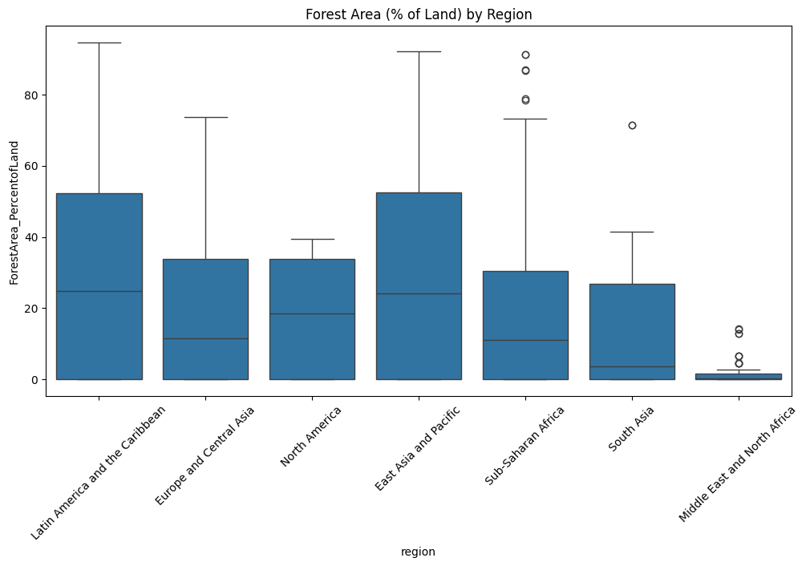

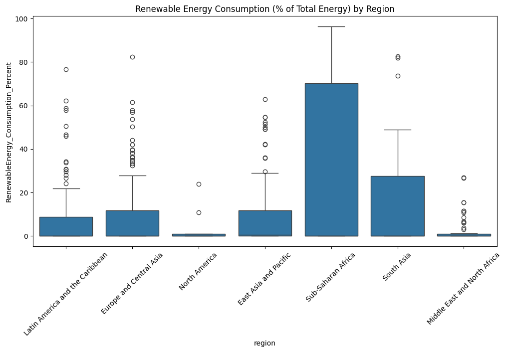

```python
def plot_boxplot(data, column, title):
    plt.figure(figsize=(12, 6))
    sns.boxplot(x="region", y=column, data=data)
    plt.xticks(rotation=45)
    plt.title(title)
    plt.show()

plot_boxplot(df_filtered, "ForestArea_PercentofLand", "Forest Area (% of Land) by Region")
plot_boxplot(df_filtered, "RenewableEnergy_Consumption_Percent", "Renewable Energy Consumption (% of Total Energy) by Region")
```

```python
zero_ghg = df_filtered[df_filtered["GreenhouseGasEmissions_TotalperCapita"] == 0]

print("Countries with Zero GHG Emissions per Capita:")
display(zero_ghg)
```

```
Countries with Zero GHG Emissions per Capita:
```

|  | country_code | year | ElectricityAccess_PercentofPopulation | CO2Emissions_Agriculture | CO2Emissions_TransportEnergy | CO2Emissions_Waste | ForestArea_PercentofLand | RenewableEnergy_Consumption_Percent | GreenhouseGasEmissions_TotalperCapita | id | country_name | region |
| --- | --- | --- | --- | --- | --- | --- | --- | --- | --- | --- | --- | --- |
| 245 | AND | 2023 | 0.0 | 0.0 | 0.0 | 0.0 | 0.000000 | 0.0 | 0.0 | NaN | Andorra | Europe and Central Asia |
| 262 | CHI | 2023 | 0.0 | 0.0 | 0.0 | 0.0 | 0.000000 | 0.0 | 0.0 | NaN | Channel Islands | Europe and Central Asia |
| 270 | CUW | 2023 | 0.0 | 0.0 | 0.0 | 0.0 | 0.000000 | 0.0 | 0.0 | NaN | Curacao | Latin America and the Caribbean |
| 289 | IMN | 2023 | 0.0 | 0.0 | 0.0 | 0.0 | 0.000000 | 0.0 | 0.0 | NaN | Isle of Man | Europe and Central Asia |
| 305 | LIE | 2023 | 0.0 | 0.0 | 0.0 | 0.0 | 0.000000 | 0.0 | 0.0 | NaN | Liechtenstein | Europe and Central Asia |
| 310 | MAF | 2023 | 0.0 | 0.0 | 0.0 | 0.0 | 0.000000 | 0.0 | 0.0 | NaN | St. Martin (French part) | Latin America and the Caribbean |
| 312 | MCO | 2023 | 0.0 | 0.0 | 0.0 | 0.0 | 0.000000 | 0.0 | 0.0 | NaN | Monaco | Europe and Central Asia |
| 315 | MNE | 2023 | 0.0 | 0.0 | 0.0 | 0.0 | 0.000000 | 0.0 | 0.0 | NaN | Montenegro | Europe and Central Asia |
| 333 | PSE | 2023 | 0.0 | 0.0 | 0.0 | 0.0 | 0.000000 | 0.0 | 0.0 | NaN | West Bank and Gaza | Middle East and North Africa |
| 345 | SMR | 2023 | 0.0 | 0.0 | 0.0 | 0.0 | 0.000000 | 0.0 | 0.0 | NaN | San Marino | Europe and Central Asia |
| 347 | SRB | 2023 | 0.0 | 0.0 | 0.0 | 0.0 | 0.000000 | 0.0 | 0.0 | NaN | Serbia | Europe and Central Asia |
| 348 | SSD | 2023 | 0.0 | 0.0 | 0.0 | 0.0 | 0.000000 | 0.0 | 0.0 | NaN | South Sudan | Sub-Saharan Africa |
| 352 | SXM | 2023 | 0.0 | 0.0 | 0.0 | 0.0 | 0.000000 | 0.0 | 0.0 | NaN | Sint Maarten (Dutch part) | Latin America and the Caribbean |
| 371 | XKX | 2021 | 0.0 | 0.0 | 0.0 | 0.0 | 0.000000 | 0.0 | 0.0 | NaN | Kosovo | Europe and Central Asia |
| 372 | XKX | 2022 | 0.0 | 0.0 | 0.0 | 0.0 | 0.000000 | 0.0 | 0.0 | NaN | Kosovo | Europe and Central Asia |
| 373 | XKX | 2023 | 0.0 | 0.0 | 0.0 | 0.0 | 0.000000 | 0.0 | 0.0 | NaN | Kosovo | Europe and Central Asia |
| 378 | SSD | 2021 | 7.7 | 0.0 | 0.0 | 0.0 | 11.325622 | 32.4 | 0.0 | NaN | South Sudan | Sub-Saharan Africa |
| 379 | SSD | 2022 | 8.4 | 0.0 | 0.0 | 0.0 | 11.325622 | 0.0 | 0.0 | NaN | South Sudan | Sub-Saharan Africa |
| 508 | MNE | 2021 | 99.8 | 0.0 | 0.0 | 0.0 | 61.486989 | 39.6 | 0.0 | NaN | Montenegro | Europe and Central Asia |
| 514 | AND | 2021 | 100.0 | 0.0 | 0.0 | 0.0 | 34.042553 | 18.4 | 0.0 | NaN | Andorra | Europe and Central Asia |
| 515 | AND | 2022 | 100.0 | 0.0 | 0.0 | 0.0 | 34.042553 | 18.7 | 0.0 | NaN | Andorra | Europe and Central Asia |
| 530 | CHI | 2021 | 100.0 | 0.0 | 0.0 | 0.0 | 5.151515 | 0.0 | 0.0 | NaN | Channel Islands | Europe and Central Asia |
| 531 | CHI | 2022 | 100.0 | 0.0 | 0.0 | 0.0 | 0.000000 | 0.0 | 0.0 | NaN | Channel Islands | Europe and Central Asia |
| 534 | CUW | 2021 | 100.0 | 0.0 | 0.0 | 0.0 | 0.157658 | 2.8 | 0.0 | NaN | Curacao | Latin America and the Caribbean |
| 535 | CUW | 2022 | 100.0 | 0.0 | 0.0 | 0.0 | 0.157658 | 0.0 | 0.0 | NaN | Curacao | Latin America and the Caribbean |
| 548 | IMN | 2021 | 100.0 | 0.0 | 0.0 | 0.0 | 6.070175 | 3.2 | 0.0 | NaN | Isle of Man | Europe and Central Asia |
| 549 | IMN | 2022 | 100.0 | 0.0 | 0.0 | 0.0 | 6.070175 | 2.7 | 0.0 | NaN | Isle of Man | Europe and Central Asia |
| 564 | LIE | 2021 | 100.0 | 0.0 | 0.0 | 0.0 | 41.875000 | 53.6 | 0.0 | NaN | Liechtenstein | Europe and Central Asia |
| 565 | LIE | 2022 | 100.0 | 0.0 | 0.0 | 0.0 | 41.875000 | 56.9 | 0.0 | NaN | Liechtenstein | Europe and Central Asia |
| 572 | MAF | 2021 | 100.0 | 0.0 | 0.0 | 0.0 | 24.800000 | 0.0 | 0.0 | NaN | St. Martin (French part) | Latin America and the Caribbean |
| 573 | MAF | 2022 | 100.0 | 0.0 | 0.0 | 0.0 | 24.800000 | 0.0 | 0.0 | NaN | St. Martin (French part) | Latin America and the Caribbean |
| 576 | MCO | 2021 | 100.0 | 0.0 | 0.0 | 0.0 | 0.000000 | 0.0 | 0.0 | NaN | Monaco | Europe and Central Asia |
| 577 | MCO | 2022 | 100.0 | 0.0 | 0.0 | 0.0 | 0.000000 | 0.0 | 0.0 | NaN | Monaco | Europe and Central Asia |
| 579 | MNE | 2022 | 100.0 | 0.0 | 0.0 | 0.0 | 61.486989 | 0.0 | 0.0 | NaN | Montenegro | Europe and Central Asia |
| 594 | PSE | 2021 | 100.0 | 0.0 | 0.0 | 0.0 | 1.682988 | 15.4 | 0.0 | NaN | West Bank and Gaza | Middle East and North Africa |
| 595 | PSE | 2022 | 100.0 | 0.0 | 0.0 | 0.0 | 0.000000 | 15.4 | 0.0 | NaN | West Bank and Gaza | Middle East and North Africa |
| 605 | SMR | 2021 | 100.0 | 0.0 | 0.0 | 0.0 | 16.666667 | 0.0 | 0.0 | NaN | San Marino | Europe and Central Asia |
| 606 | SMR | 2022 | 100.0 | 0.0 | 0.0 | 0.0 | 16.666667 | 0.0 | 0.0 | NaN | San Marino | Europe and Central Asia |
| 607 | SRB | 2021 | 100.0 | 0.0 | 0.0 | 0.0 | 32.381258 | 27.2 | 0.0 | NaN | Serbia | Europe and Central Asia |
| 608 | SRB | 2022 | 100.0 | 0.0 | 0.0 | 0.0 | 32.385816 | 0.0 | 0.0 | NaN | Serbia | Europe and Central Asia |
| 611 | SXM | 2021 | 100.0 | 0.0 | 0.0 | 0.0 | 10.882353 | 0.0 | 0.0 | NaN | Sint Maarten (Dutch part) | Latin America and the Caribbean |
| 612 | SXM | 2022 | 100.0 | 0.0 | 0.0 | 0.0 | 10.882353 | 0.0 | 0.0 | NaN | Sint Maarten (Dutch part) | Latin America and the Caribbean |

### **Preprocessing for Indicators: Greenhouse Gas Emissions per Capita**

```python
outliers_ghg = detect_outliers_iqr(df_filtered, "GreenhouseGasEmissions_TotalperCapita")

print("Outliers in Total GHG Emissions per Capita (t CO₂e/capita):")
display(outliers_ghg)
```

```
Outliers in Total GHG Emissions per Capita (t CO₂e/capita):
```

|  | country_name | region | GreenhouseGasEmissions_TotalperCapita |
| --- | --- | --- | --- |
| 6 | Canada | North America | 18.646378 |
| 59 | New Zealand | East Asia and Pacific | 16.122571 |
| 165 | Australia | East Asia and Pacific | 22.609635 |
| 168 | Canada | North America | 19.044730 |
| 169 | Canada | North America | 19.138756 |
| 246 | United Arab Emirates | Middle East and North Africa | 25.546505 |
| 255 | Bahrain | Middle East and North Africa | 40.413136 |
| 321 | New Caledonia | East Asia and Pacific | 22.817815 |
| 328 | Oman | Middle East and North Africa | 25.239891 |
| 331 | Palau | East Asia and Pacific | 84.712585 |
| 336 | Qatar | Middle East and North Africa | 58.125655 |
| 337 | Russian Federation | Europe and Central Asia | 18.578261 |
| 339 | Saudi Arabia | Middle East and North Africa | 24.204877 |
| 360 | Trinidad and Tobago | Latin America and the Caribbean | 24.999452 |
| 516 | United Arab Emirates | Middle East and North Africa | 26.836639 |
| 517 | United Arab Emirates | Middle East and North Africa | 26.564120 |
| 522 | Bahrain | Middle East and North Africa | 42.135918 |
| 523 | Bahrain | Middle East and North Africa | 40.995466 |
| 556 | Kazakhstan | Europe and Central Asia | 16.370523 |
| 557 | Kazakhstan | Europe and Central Asia | 16.018136 |
| 582 | New Caledonia | East Asia and Pacific | 21.029823 |
| 583 | New Caledonia | East Asia and Pacific | 21.863452 |
| 588 | Oman | Middle East and North Africa | 26.632624 |
| 589 | Oman | Middle East and North Africa | 26.477065 |
| 590 | Palau | East Asia and Pacific | 78.147669 |
| 591 | Palau | East Asia and Pacific | 82.335717 |
| 598 | Qatar | Middle East and North Africa | 57.139458 |
| 599 | Qatar | Middle East and North Africa | 54.364620 |
| 600 | Russian Federation | Europe and Central Asia | 17.602849 |
| 601 | Russian Federation | Europe and Central Asia | 18.175081 |
| 602 | Saudi Arabia | Middle East and North Africa | 24.401350 |
| 603 | Saudi Arabia | Middle East and North Africa | 24.458422 |
| 621 | Trinidad and Tobago | Latin America and the Caribbean | 25.884094 |
| 622 | Trinidad and Tobago | Latin America and the Caribbean | 25.481383 |
| 666 | Kuwait | Middle East and North Africa | 34.597418 |
| 671 | Kuwait | Middle East and North Africa | 36.185619 |
| 672 | Kuwait | Middle East and North Africa | 36.033609 |
| 680 | Gibraltar | Europe and Central Asia | 18.517845 |
| 681 | Gibraltar | Europe and Central Asia | 18.167019 |
| 682 | Gibraltar | Europe and Central Asia | 18.570023 |
| 693 | Mongolia | East Asia and Pacific | 24.045135 |
| 697 | Mongolia | East Asia and Pacific | 19.887338 |
| 698 | Mongolia | East Asia and Pacific | 19.476997 |
| 718 | Brunei Darussalam | East Asia and Pacific | 26.490743 |
| 719 | Brunei Darussalam | East Asia and Pacific | 27.300701 |
| 720 | Brunei Darussalam | East Asia and Pacific | 26.104706 |
| 729 | New Zealand | East Asia and Pacific | 16.544186 |
| 730 | New Zealand | East Asia and Pacific | 16.295826 |
| 759 | United States | North America | 17.797967 |
| 760 | United States | North America | 18.062548 |
| 761 | United States | North America | 18.142017 |
| 795 | Australia | East Asia and Pacific | 21.450201 |
| 797 | Australia | East Asia and Pacific | 21.872898 |

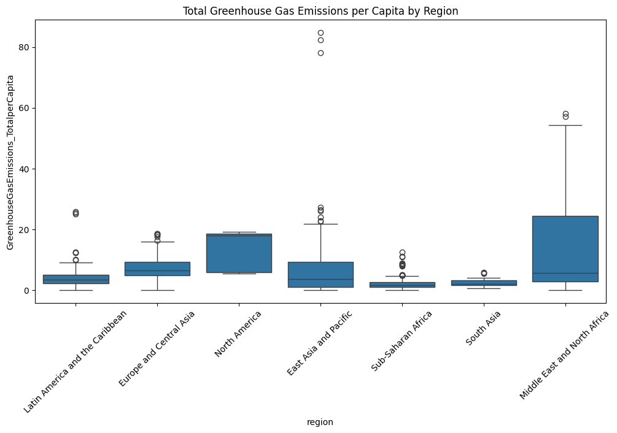

```python
plot_boxplot(df_filtered, "GreenhouseGasEmissions_TotalperCapita", "Total Greenhouse Gas Emissions per Capita by Region")
```

**Expected range for tCO2 e/capita is 2-20, review values outside of that range**

```python
invalid_ghg = df_filtered[(df_filtered["GreenhouseGasEmissions_TotalperCapita"] < 2) |
                          (df_filtered["GreenhouseGasEmissions_TotalperCapita"] > 20)]
print("Countries with GHG Emissions Outside Expected Range (2-20 t CO₂e/capita):")
display(invalid_ghg)
```

```
Countries with GHG Emissions Outside Expected Range (2-20 t CO₂e/capita):
```

|  | country_code | year | ElectricityAccess_PercentofPopulation | CO2Emissions_Agriculture | CO2Emissions_TransportEnergy | CO2Emissions_Waste | ForestArea_PercentofLand | RenewableEnergy_Consumption_Percent | GreenhouseGasEmissions_TotalperCapita | id | country_name | region |
| --- | --- | --- | --- | --- | --- | --- | --- | --- | --- | --- | --- | --- |
| 42 | KEN | 2023 | 0.0 | 0.2002 | 10.6148 | 0.0015 | 0.000000 | 0.0 | 1.562589 | NaN | Kenya | Sub-Saharan Africa |
| 89 | MLI | 2022 | 53.0 | 0.1636 | 3.4212 | 0.0105 | 10.896664 | 71.1 | 1.562589 | NaN | Mali | Sub-Saharan Africa |
| 91 | ETH | 2021 | 54.2 | 0.4032 | 7.1509 | 0.0015 | 15.059304 | 90.6 | 1.562589 | NaN | Ethiopia | Sub-Saharan Africa |
| 244 | AGO | 2023 | 0.0 | 0.0000 | 8.4967 | 0.0000 | 0.000000 | 0.0 | 1.562589 | NaN | Angola | Sub-Saharan Africa |
| 252 | BDI | 2023 | 0.0 | 0.0000 | 0.4063 | 0.0000 | 0.000000 | 0.0 | 1.562589 | NaN | Burundi | Sub-Saharan Africa |
| 253 | BFA | 2023 | 0.0 | 0.0000 | 2.7255 | 0.0000 | 0.000000 | 0.0 | 1.562589 | NaN | Burkina Faso | Sub-Saharan Africa |
| 263 | CIV | 2023 | 0.0 | 0.1360 | 5.1628 | 0.0000 | 0.000000 | 0.0 | 1.562589 | NaN | Cote d'Ivoire | Sub-Saharan Africa |
| 264 | CMR | 2023 | 0.0 | 0.0761 | 4.2671 | 0.0000 | 0.000000 | 0.0 | 1.562589 | NaN | Cameroon | Sub-Saharan Africa |
| 265 | COD | 2023 | 0.0 | 0.0000 | 2.7708 | 0.0000 | 0.000000 | 0.0 | 1.562589 | NaN | Congo, Dem. Rep. | Sub-Saharan Africa |
| 267 | COM | 2023 | 0.0 | 0.0000 | 0.1808 | 0.0000 | 0.000000 | 0.0 | 1.562589 | NaN | Comoros | Sub-Saharan Africa |
| 274 | ERI | 2023 | 0.0 | 0.0000 | 0.2105 | 0.0000 | 0.000000 | 0.0 | 1.562589 | NaN | Eritrea | Sub-Saharan Africa |
| 279 | GHA | 2023 | 0.0 | 0.0000 | 9.0355 | 0.0000 | 0.000000 | 0.0 | 1.562589 | NaN | Ghana | Sub-Saharan Africa |
| 280 | GIN | 2023 | 0.0 | 0.0000 | 1.7540 | 0.0000 | 0.000000 | 0.0 | 1.562589 | NaN | Guinea | Sub-Saharan Africa |
| 281 | GMB | 2023 | 0.0 | 0.0000 | 0.3439 | 0.0000 | 0.000000 | 0.0 | 1.562589 | NaN | Gambia, The | Sub-Saharan Africa |
| 282 | GNB | 2023 | 0.0 | 0.0000 | 0.1957 | 0.0000 | 0.000000 | 0.0 | 1.562589 | NaN | Guinea-Bissau | Sub-Saharan Africa |
| 302 | LBR | 2023 | 0.0 | 0.0000 | 0.8101 | 0.0000 | 0.000000 | 0.0 | 1.562589 | NaN | Liberia | Sub-Saharan Africa |
| 307 | LSO | 2023 | 0.0 | 0.0000 | 0.4992 | 0.0000 | 0.000000 | 0.0 | 1.562589 | NaN | Lesotho | Sub-Saharan Africa |
| 313 | MDG | 2023 | 0.0 | 0.0000 | 1.3562 | 0.0000 | 0.000000 | 0.0 | 1.562589 | NaN | Madagascar | Sub-Saharan Africa |
| 317 | MOZ | 2023 | 0.0 | 0.0000 | 3.9254 | 0.0000 | 0.000000 | 0.0 | 1.562589 | NaN | Mozambique | Sub-Saharan Africa |
| 319 | MWI | 2023 | 0.0 | 0.0000 | 0.7669 | 0.0000 | 0.000000 | 0.0 | 1.562589 | NaN | Malawi | Sub-Saharan Africa |
| 322 | NER | 2023 | 0.0 | 0.0000 | 1.2671 | 0.0000 | 0.000000 | 0.0 | 1.562589 | NaN | Niger | Sub-Saharan Africa |
| 323 | NGA | 2023 | 0.0 | 1.6800 | 57.8574 | 0.0000 | 0.000000 | 0.0 | 1.562589 | NaN | Nigeria | Sub-Saharan Africa |
| 338 | RWA | 2023 | 0.0 | 0.0000 | 0.5963 | 0.0000 | 0.000000 | 0.0 | 1.562589 | NaN | Rwanda | Sub-Saharan Africa |
| 341 | SEN | 2023 | 0.0 | 0.0063 | 3.4308 | 0.0000 | 0.000000 | 0.0 | 1.562589 | NaN | Senegal | Sub-Saharan Africa |
| 343 | SLE | 2023 | 0.0 | 0.0000 | 0.5260 | 0.0000 | 0.000000 | 0.0 | 1.562589 | NaN | Sierra Leone | Sub-Saharan Africa |
| 346 | SOM | 2023 | 0.0 | 0.0000 | 0.4792 | 0.0000 | 0.000000 | 0.0 | 1.562589 | NaN | Somalia | Sub-Saharan Africa |
| 348 | SSD | 2023 | 0.0 | 0.0000 | 0.0000 | 0.0000 | 0.000000 | 0.0 | 1.562589 | NaN | South Sudan | Sub-Saharan Africa |
| 349 | STP | 2023 | 0.0 | 0.0000 | 0.1219 | 0.0000 | 0.000000 | 0.0 | 1.562589 | NaN | Sao Tome and Principe | Sub-Saharan Africa |
| 363 | TZA | 2023 | 0.0 | 0.1231 | 8.9100 | 0.0000 | 0.000000 | 0.0 | 1.562589 | NaN | Tanzania | Sub-Saharan Africa |
| 364 | UGA | 2023 | 0.0 | 0.0000 | 3.5450 | 0.0000 | 0.000000 | 0.0 | 1.562589 | NaN | Uganda | Sub-Saharan Africa |

[output cut: 71 more lines]

**Calculate median for GHG emissions per capita by REGION**

**Apply median imputation to replace GHG values outside of the expected range with the median**

```python
regional_medians = df_filtered.groupby("region")["GreenhouseGasEmissions_TotalperCapita"].transform("median")

df_filtered["GreenhouseGasEmissions_TotalperCapita"] = df_filtered["GreenhouseGasEmissions_TotalperCapita"].mask(
    (df_filtered["GreenhouseGasEmissions_TotalperCapita"] < 2) |
    (df_filtered["GreenhouseGasEmissions_TotalperCapita"] > 20),
    regional_medians
)
```

## **Final Summary Statistics Post-Cleaning: Environmental_Indicators table**

```python
summary_stats = df_filtered.describe()

print("Summary Statistics for Cleaned Environmental Data:")
display(summary_stats)
```

```
Summary Statistics for Cleaned Environmental Data:
```

|  | year | ElectricityAccess_PercentofPopulation | CO2Emissions_Agriculture | CO2Emissions_TransportEnergy | CO2Emissions_Waste | ForestArea_PercentofLand | RenewableEnergy_Consumption_Percent | GreenhouseGasEmissions_TotalperCapita | id |
| --- | --- | --- | --- | --- | --- | --- | --- | --- | --- |
| count | 651.000000 | 651.000000 | 651.000000 | 651.000000 | 651.000000 | 651.000000 | 651.000000 | 651.000000 | 0.0 |
| mean | 2022.000000 | 57.686329 | 0.659125 | 31.301669 | 0.082112 | 20.813293 | 12.695084 | 5.274624 | NaN |
| std | 0.817124 | 45.525254 | 2.598141 | 137.965376 | 0.466856 | 24.726896 | 23.559641 | 3.644348 | NaN |
| min | 2021.000000 | 0.000000 | 0.000000 | 0.000000 | 0.000000 | 0.000000 | 0.000000 | 1.562589 | NaN |
| 25% | 2021.000000 | 0.000000 | 0.000000 | 0.481650 | 0.000000 | 0.000000 | 0.000000 | 2.710744 | NaN |
| 50% | 2022.000000 | 85.300000 | 0.000000 | 2.825200 | 0.000000 | 10.889408 | 0.000000 | 4.268287 | NaN |
| 75% | 2023.000000 | 100.000000 | 0.181700 | 13.675450 | 0.002200 | 37.177772 | 13.100000 | 6.494900 | NaN |
| max | 2023.000000 | 100.000000 | 30.582700 | 1710.645400 | 4.175800 | 94.600146 | 96.300000 | 19.887338 | NaN |

## **Export cleaned table to .csv**

```python
export_path = "/content/cleaned_environmental_indicators.csv"

df_filtered.to_csv(export_path, index=False)

print("Cleaned dataset saved as: {export_path}")
```

[output not shown]

```python
!jupyter nbconvert --to html "/content/BANA698_Environmental_Preprocessing.ipynb"
```

```
[NbConvertApp] Converting notebook /content/BANA698_Environmental_Preprocessing.ipynb to html
[NbConvertApp] WARNING | Alternative text is missing on 12 image(s).
[NbConvertApp] Writing 1523059 bytes to /content/BANA698_Environmental_Preprocessing.html
```